# US Filghts Data Exploration

## Preliminary Wrangling

> The dataset include flights info of the United States, about carriers, arrival and departure delays, and reasons for delays, from 1987 to 2008.

```python
# import all packages and set plots to be embedded inline
import numpy as np
import pandas as pd
import matplotlib.pyplot as plt
import seaborn as sns

%matplotlib inline
```

```python
# Showing all column/row name in the dataset
pd.set_option('display.max_columns', None)
pd.set_option('display.max_rows', None)
```

> Load the data set.

```python
df_flight_1987 = pd.read_csv('../Dataset/1987.csv')
df_flight_1987.head(2)
```

|  | Year | Month | DayofMonth | DayOfWeek | DepTime | CRSDepTime | ArrTime | CRSArrTime | UniqueCarrier | FlightNum | TailNum | ActualElapsedTime | CRSElapsedTime | AirTime | ArrDelay | DepDelay | Origin | Dest | Distance | TaxiIn | TaxiOut | Cancelled | CancellationCode | Diverted | CarrierDelay | WeatherDelay | NASDelay | SecurityDelay | LateAircraftDelay |
| --- | --- | --- | --- | --- | --- | --- | --- | --- | --- | --- | --- | --- | --- | --- | --- | --- | --- | --- | --- | --- | --- | --- | --- | --- | --- | --- | --- | --- | --- |
| 0 | 1987 | 10 | 14 | 3 | 741.0 | 730 | 912.0 | 849 | PS | 1451 | NaN | 91.0 | 79 | NaN | 23.0 | 11.0 | SAN | SFO | 447.0 | NaN | NaN | 0 | NaN | 0 | NaN | NaN | NaN | NaN | NaN |
| 1 | 1987 | 10 | 15 | 4 | 729.0 | 730 | 903.0 | 849 | PS | 1451 | NaN | 94.0 | 79 | NaN | 14.0 | -1.0 | SAN | SFO | 447.0 | NaN | NaN | 0 | NaN | 0 | NaN | NaN | NaN | NaN | NaN |

```python
# check for shape and duplication
print(df_flight_1987.shape)
df_flight_1987.duplicated == True
```

```
(1311826, 29)
```

```
False
```

```python
# # know we will load 1987 to 2008 years of US flight dataset
# # and concat it in one dataset for exploration
# # star by the 1987 to 1999 year dataframe to concat others with it
# df_flights_19 = pd.read_csv('../Dataset/1987.csv')
# for n in range(1988,1999):
#     df1 = pd.read_csv('../Dataset/'+str(n)+'.csv')
#     df_flights_19 = df_flights_19.append(df1, ignore_index=True)

# Save the loop result (dataframe) for future use, because the concatenation process take long time
# and make the loop above commented to didn't run again
# df_flights.to_csv ('../Dataset/US_Flights_1987to2008.csv', index = None, header=True) #Don't forget to add '.csv' at the end of the path
```

Beacuse if we concate all years in website from 1987 to 2008 together the dataset will be huge, so I will explore 2008 year then may or may not concat all year avalibe in website/ or may concat 2000 years .. but for this project I think 2008 year is enough ..

```python
df_flight_2008 = pd.read_csv('../Dataset/2008.csv')
```

```python
df_flight_2008.shape # more than 7 million rows!
```

```
(7009728, 29)
```

```python
# check duplication for data exploration!
df_flight_2008.duplicated == True
```

```
False
```

```python
df_flight_2008.head()
```

|  | Year | Month | DayofMonth | DayOfWeek | DepTime | CRSDepTime | ArrTime | CRSArrTime | UniqueCarrier | FlightNum | TailNum | ActualElapsedTime | CRSElapsedTime | AirTime | ArrDelay | DepDelay | Origin | Dest | Distance | TaxiIn | TaxiOut | Cancelled | CancellationCode | Diverted | CarrierDelay | WeatherDelay | NASDelay | SecurityDelay | LateAircraftDelay |
| --- | --- | --- | --- | --- | --- | --- | --- | --- | --- | --- | --- | --- | --- | --- | --- | --- | --- | --- | --- | --- | --- | --- | --- | --- | --- | --- | --- | --- | --- |
| 0 | 2008 | 1 | 3 | 4 | 2003.0 | 1955 | 2211.0 | 2225 | WN | 335 | N712SW | 128.0 | 150.0 | 116.0 | -14.0 | 8.0 | IAD | TPA | 810 | 4.0 | 8.0 | 0 | NaN | 0 | NaN | NaN | NaN | NaN | NaN |
| 1 | 2008 | 1 | 3 | 4 | 754.0 | 735 | 1002.0 | 1000 | WN | 3231 | N772SW | 128.0 | 145.0 | 113.0 | 2.0 | 19.0 | IAD | TPA | 810 | 5.0 | 10.0 | 0 | NaN | 0 | NaN | NaN | NaN | NaN | NaN |
| 2 | 2008 | 1 | 3 | 4 | 628.0 | 620 | 804.0 | 750 | WN | 448 | N428WN | 96.0 | 90.0 | 76.0 | 14.0 | 8.0 | IND | BWI | 515 | 3.0 | 17.0 | 0 | NaN | 0 | NaN | NaN | NaN | NaN | NaN |
| 3 | 2008 | 1 | 3 | 4 | 926.0 | 930 | 1054.0 | 1100 | WN | 1746 | N612SW | 88.0 | 90.0 | 78.0 | -6.0 | -4.0 | IND | BWI | 515 | 3.0 | 7.0 | 0 | NaN | 0 | NaN | NaN | NaN | NaN | NaN |
| 4 | 2008 | 1 | 3 | 4 | 1829.0 | 1755 | 1959.0 | 1925 | WN | 3920 | N464WN | 90.0 | 90.0 | 77.0 | 34.0 | 34.0 | IND | BWI | 515 | 3.0 | 10.0 | 0 | NaN | 0 | 2.0 | 0.0 | 0.0 | 0.0 | 32.0 |

```python
df_flight_2008.info()
```

```
<class 'pandas.core.frame.DataFrame'>
RangeIndex: 7009728 entries, 0 to 7009727
Data columns (total 29 columns):
Year                 int64
Month                int64
DayofMonth           int64
DayOfWeek            int64
DepTime              float64
CRSDepTime           int64
ArrTime              float64
CRSArrTime           int64
UniqueCarrier        object
FlightNum            int64
TailNum              object
ActualElapsedTime    float64
CRSElapsedTime       float64
AirTime              float64
ArrDelay             float64
DepDelay             float64
Origin               object
Dest                 object
Distance             int64
TaxiIn               float64
TaxiOut              float64
Cancelled            int64
CancellationCode     object
Diverted             int64
CarrierDelay         float64
WeatherDelay         float64
NASDelay             float64
SecurityDelay        float64
LateAircraftDelay    float64
dtypes: float64(14), int64(10), object(5)
memory usage: 1.5+ GB
```

*** please note the Diverted & Cancelled columns their values are 0 and 1 (which means 1 = yes, 0 = no)

```python
# get object feature to know what is it content values
df_flight_2008.dtypes == object
```

```
Year                 False
Month                False
DayofMonth           False
DayOfWeek            False
DepTime              False
CRSDepTime           False
ArrTime              False
CRSArrTime           False
UniqueCarrier         True
FlightNum            False
TailNum               True
ActualElapsedTime    False
CRSElapsedTime       False
AirTime              False
ArrDelay             False
DepDelay             False
Origin                True
Dest                  True
Distance             False
TaxiIn               False
TaxiOut              False
Cancelled            False
CancellationCode      True
Diverted             False
CarrierDelay         False
WeatherDelay         False
NASDelay             False
SecurityDelay        False
LateAircraftDelay    False
dtype: bool
```

###### These feature are object type other are numberic

UniqueCarrier  
TailNum - missing values = 83365  
Origin  
Dest  
CancellationCode - missing values = 6872294

```python
# check columns include NaN, to didn't use it in this stage of exploration
df_flight_2008.isna().sum().sort_values(ascending=False)
```

```
CancellationCode     6872294
LateAircraftDelay    5484993
SecurityDelay        5484993
NASDelay             5484993
WeatherDelay         5484993
CarrierDelay         5484993
ActualElapsedTime     154699
AirTime               154699
ArrDelay              154699
TaxiIn                151649
ArrTime               151649
TaxiOut               137058
DepDelay              136246
DepTime               136246
TailNum                83365
CRSElapsedTime           844
CRSArrTime                 0
Month                      0
DayofMonth                 0
DayOfWeek                  0
CRSDepTime                 0
FlightNum                  0
UniqueCarrier              0
Distance                   0
Diverted                   0
Cancelled                  0
Origin                     0
Dest                       0
Year                       0
dtype: int64
```

**Please note because I will not go in Wangling part we will not foucs on columns with missing value which are:**

CancellationCode, LateAircraftDelay, SecurityDelay, NASDelay, WeatherDelay, CarrierDelay, ActualElapsedTime, AirTime, ArrDelay, TaxiIn, ArrTim, TaxiOut, DepDelay, DepTime, TailNum, CRSElapsedTime

```python
# drop column with missing values to don't foucs on ..
# df_flight_2008.dropna(axis=1, inplace=True)
```

```python
# df_flight_2008.info()
```

```python
df_flight_2008.FlightNum.value_counts()
df_flight_2008.FlightNum.isna().sum()
```

```
0
```

```python
df_flight_2008.TailNum.value_counts()
df_flight_2008.FlightNum.isna().sum()
```

```
0
```

```python
df_flight_2008.Diverted.value_counts()
```

```
0    6992463
1      17265
Name: Diverted, dtype: int64
```

Check below the "CancellationCode" for both "Diverted" and "Cancelled" varibles when equals to 1 and 0

```python
df_flight_2008.CancellationCode[df_flight_2008.Diverted == 0].value_counts()
```

```
B    54904
A    54330
C    28188
D       12
Name: CancellationCode, dtype: int64
```

```python
df_flight_2008.CancellationCode[df_flight_2008.Diverted == 1].value_counts()
```

```
Series([], Name: CancellationCode, dtype: int64)
```

```python
df_flight_2008.CancellationCode[df_flight_2008.Cancelled == 0].value_counts()
```

```
Series([], Name: CancellationCode, dtype: int64)
```

```python
df_flight_2008.CancellationCode[df_flight_2008.Cancelled == 1].value_counts()
```

```
B    54904
A    54330
C    28188
D       12
Name: CancellationCode, dtype: int64
```

```python
# show the count of each "FlightNum" that have "CancellationCode" values
df_flight_2008.FlightNum[df_flight_2008.CancellationCode != 'NaN'].value_counts()
```

```
152     4883
12      4793
16      4717
511     4621
308     4449
73      4330
623     4262
321     4234
197     4190
15      4189
180     4147
403     4108
369     4078
307     4078
65      4053
```

[output cut: 7525 more lines]

```python
# show the dataframe where the CancellationCode != 'NaN'
df_flight_2008[~df_flight_2008.CancellationCode.isna()].head()
```

|  | Year | Month | DayofMonth | DayOfWeek | DepTime | CRSDepTime | ArrTime | CRSArrTime | UniqueCarrier | FlightNum | TailNum | ActualElapsedTime | CRSElapsedTime | AirTime | ArrDelay | DepDelay | Origin | Dest | Distance | TaxiIn | TaxiOut | Cancelled | CancellationCode | Diverted | CarrierDelay | WeatherDelay | NASDelay | SecurityDelay | LateAircraftDelay |
| --- | --- | --- | --- | --- | --- | --- | --- | --- | --- | --- | --- | --- | --- | --- | --- | --- | --- | --- | --- | --- | --- | --- | --- | --- | --- | --- | --- | --- | --- |
| 178 | 2008 | 1 | 3 | 4 | NaN | 700 | NaN | 830 | WN | 126 | NaN | NaN | 90.0 | NaN | NaN | NaN | LAS | OAK | 407 | NaN | NaN | 1 | A | 0 | NaN | NaN | NaN | NaN | NaN |
| 373 | 2008 | 1 | 3 | 4 | NaN | 1100 | NaN | 1215 | WN | 1146 | NaN | NaN | 75.0 | NaN | NaN | NaN | LAX | OAK | 337 | NaN | NaN | 1 | A | 0 | NaN | NaN | NaN | NaN | NaN |
| 399 | 2008 | 1 | 3 | 4 | NaN | 905 | NaN | 1025 | WN | 469 | NaN | NaN | 80.0 | NaN | NaN | NaN | LAX | SFO | 337 | NaN | NaN | 1 | A | 0 | NaN | NaN | NaN | NaN | NaN |
| 401 | 2008 | 1 | 3 | 4 | NaN | 1620 | NaN | 1740 | WN | 618 | NaN | NaN | 80.0 | NaN | NaN | NaN | LAX | SFO | 337 | NaN | NaN | 1 | C | 0 | NaN | NaN | NaN | NaN | NaN |
| 415 | 2008 | 1 | 3 | 4 | NaN | 1930 | NaN | 2035 | WN | 2528 | NaN | NaN | 65.0 | NaN | NaN | NaN | LAX | SJC | 308 | NaN | NaN | 1 | A | 0 | NaN | NaN | NaN | NaN | NaN |

```python
df_flight_2008.head(50)
```

[output not shown]

### What is the structure of your dataset?

> US flights info in 2008 have 7009728 observations and 29 features. the detail od columns' value are in http://stat-computing.org/dataexpo/2009/the-data.html as below (categorize by type of variables)

> columns' values are day and year:  
> 1 Year - 1987-2008  
> 2 Month - 1-12  
> 3 DayofMonth - 1-31  
> 4 DayOfWeek - 1 (Monday) - 7 (Sunday)

> columns' value are time (local, hhmm):  
> 5 DepTime - actual departure  
> 6 CRSDepTime - scheduled departure  
> 7 ArrTime - actual arrival  
> 8 CRSArrTime - scheduled arrival

> These columns' value are in minutes:  
> 12 ActualElapsedTime  
> 13 CRSElapsedTime  
> 14 AirTime  
> 15 ArrDelay  
> 16 DepDelay  
> 20 TaxiIn  
> 21 TaxiOut  
> 25 CarrierDelay  
> 26 WeatherDelay  
> 27 NASDelay  
> 28 SecurityDelay  
> 29 LateAircraftDelay

> column's value is in miles:  
> 19 Distance

> other columns' value:  
> 9 UniqueCarrier - unique carrier code  
> 10 FlightNum - flight number  
> 11 TailNum plane - tail number

> 17 Origin - origin IATA airport code  
> 18 Dest - destination IATA airport code

> 22 Cancelled - was the flight cancelled? (0,1)  
> 23 CancellationCode - reason for cancellation (A = carrier, B = weather, C = NAS, D = security)  
> 24 Diverted - 1 = yes, 0 = no

### What is/are the main feature(s) of interest in your dataset?

> "Month", "DayofMonth" and "DayOfWeek" to explore month/days of flight cancellation. (in future may compine all years to include Years to investigation)

> "Distance" of flight cancellation

> "CancellationCode" the reson of cancellation, which are "CarrierDelay", "WeatherDelay", "NASDelay" or "SecurityDelay"

> "UniqueCarrier"

### What features in the dataset do you think will help support your investigation into your feature(s) of interest?

> "FlightNum" find number of canccelations flight of each interesting feature.

## Univariate Exploration

```python
df_flight_2008.head()
```

|  | Year | Month | DayofMonth | DayOfWeek | DepTime | CRSDepTime | ArrTime | CRSArrTime | UniqueCarrier | FlightNum | TailNum | ActualElapsedTime | CRSElapsedTime | AirTime | ArrDelay | DepDelay | Origin | Dest | Distance | TaxiIn | TaxiOut | Cancelled | CancellationCode | Diverted | CarrierDelay | WeatherDelay | NASDelay | SecurityDelay | LateAircraftDelay |
| --- | --- | --- | --- | --- | --- | --- | --- | --- | --- | --- | --- | --- | --- | --- | --- | --- | --- | --- | --- | --- | --- | --- | --- | --- | --- | --- | --- | --- | --- |
| 0 | 2008 | 1 | 3 | 4 | 2003.0 | 1955 | 2211.0 | 2225 | WN | 335 | N712SW | 128.0 | 150.0 | 116.0 | -14.0 | 8.0 | IAD | TPA | 810 | 4.0 | 8.0 | 0 | NaN | 0 | NaN | NaN | NaN | NaN | NaN |
| 1 | 2008 | 1 | 3 | 4 | 754.0 | 735 | 1002.0 | 1000 | WN | 3231 | N772SW | 128.0 | 145.0 | 113.0 | 2.0 | 19.0 | IAD | TPA | 810 | 5.0 | 10.0 | 0 | NaN | 0 | NaN | NaN | NaN | NaN | NaN |
| 2 | 2008 | 1 | 3 | 4 | 628.0 | 620 | 804.0 | 750 | WN | 448 | N428WN | 96.0 | 90.0 | 76.0 | 14.0 | 8.0 | IND | BWI | 515 | 3.0 | 17.0 | 0 | NaN | 0 | NaN | NaN | NaN | NaN | NaN |
| 3 | 2008 | 1 | 3 | 4 | 926.0 | 930 | 1054.0 | 1100 | WN | 1746 | N612SW | 88.0 | 90.0 | 78.0 | -6.0 | -4.0 | IND | BWI | 515 | 3.0 | 7.0 | 0 | NaN | 0 | NaN | NaN | NaN | NaN | NaN |
| 4 | 2008 | 1 | 3 | 4 | 1829.0 | 1755 | 1959.0 | 1925 | WN | 3920 | N464WN | 90.0 | 90.0 | 77.0 | 34.0 | 34.0 | IND | BWI | 515 | 3.0 | 10.0 | 0 | NaN | 0 | 2.0 | 0.0 | 0.0 | 0.0 | 32.0 |

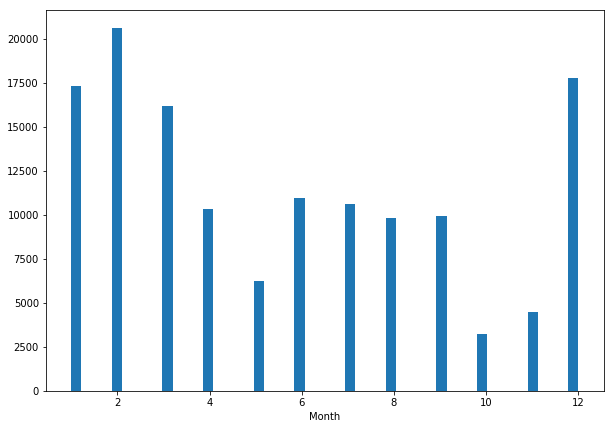

```python
# plot distribution of Month where there are cancalation
plt.figure(figsize=[10, 7])
plt.hist(df_flight_2008.Month[df_flight_2008.Cancelled == 1], bins=50)
plt.xlabel('Month');
```

We can see that the most Month have flight cancelation are 2 and 12 in 2008 year

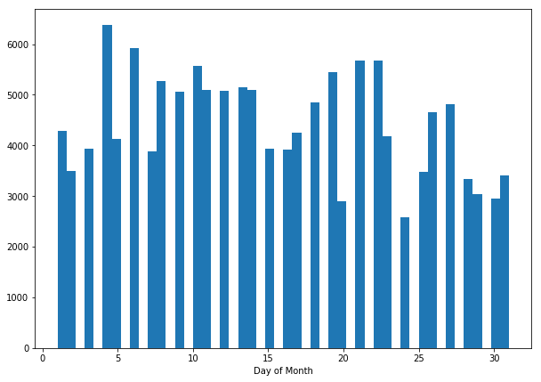

```python
# plot distribution of DayofMonth/DayOfWeek where there are cancalation
plt.figure(figsize=[10, 7])
plt.hist(df_flight_2008.DayofMonth[df_flight_2008.Cancelled == 1], bins=50)
plt.xlabel('Day of Month');
```

```
Text(0.5,0,'Day of Week')
```

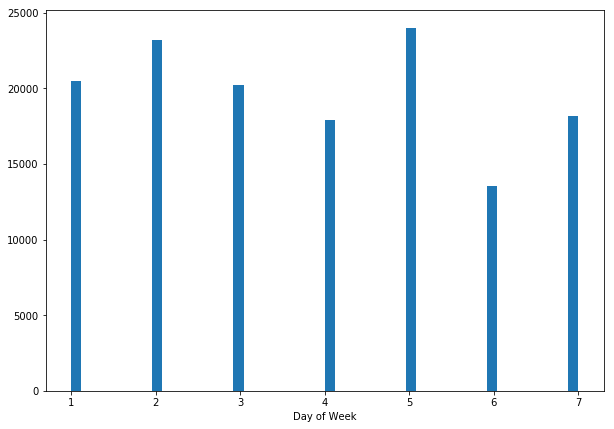

```python
# DayOfWeek 1 (Monday) - 7 (Sunday)
plt.figure(figsize=[10, 7])
plt.hist(df_flight_2008.DayOfWeek[df_flight_2008.Cancelled == 1], bins=50)
plt.xlabel('Day of Week')
```

The day #6 which is "Saturday" have the least cancellation of flight in 2008 (It's weekend so may that why have the least cancellation because the flight may will fully or it is important to make sure the flight goes to its destination for some purposes)

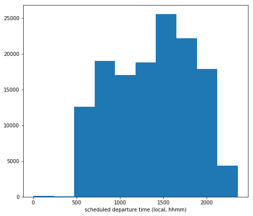

```python
# scheduled departure time (local, hhmm)
plt.figure(figsize=[8, 7])
plt.hist(df_flight_2008.CRSDepTime[df_flight_2008.Cancelled == 1])
plt.xlabel('scheduled departure time (local, hhmm)');
```

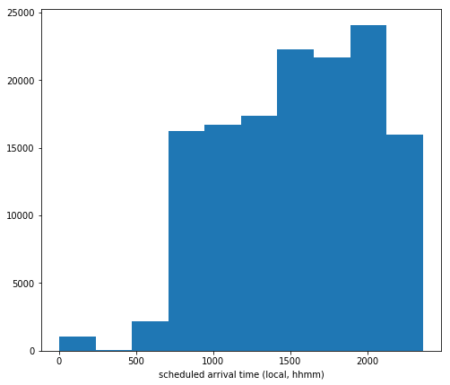

```python
# scheduled arrival time (local, hhmm)
plt.figure(figsize=[8, 7])
plt.hist(df_flight_2008.CRSArrTime[df_flight_2008.Cancelled == 1])
plt.xlabel('scheduled arrival time (local, hhmm)');
```

Hours between 15:00 to 20:00 have the most cancellation flights in general for both:

- CRSDepTime - scheduled departure time (local, hhmm)
- CRSArrTime - scheduled arrival time (local, hhmm)

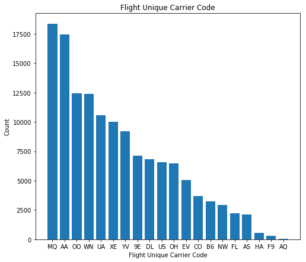

```python
# UniqueCarrier
UniqueCarrier_series = df_flight_2008.UniqueCarrier[df_flight_2008.Cancelled == 1]
dict_UniqueCarrier_series = dict(UniqueCarrier_series.value_counts())

plt.figure(figsize=[8, 7])
plt.bar(dict_UniqueCarrier_series.keys(), dict_UniqueCarrier_series.values())
plt.title('Flight Unique Carrier Code')
plt.ylabel('Count')
plt.xlabel('Flight Unique Carrier Code');
```

"MQ" and "AA" Unique Carrier code have the most cancellation flights, and the least are "HA", "F9" and "AQ"!  
** for further information about unique carrier code look at this csv http://stat-computing.org/dataexpo/2009/carriers.csv or look at original data description web page http://stat-computing.org/dataexpo/2009/the-data.html

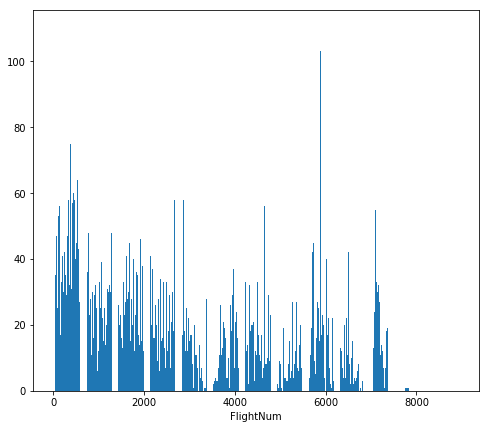

```python
# FlightNum
# plot bars of FlightNum where there are cancalation
FlightNum_series = df_flight_2008.FlightNum[df_flight_2008.Cancelled == 1]
dict_FlightNum_series = dict(FlightNum_series.value_counts())

plt.figure(figsize=[8, 7])
plt.bar(dict_FlightNum_series.keys(), dict_FlightNum_series.values())
plt.xlabel('FlightNum');
```

```python
FlightNum_series.value_counts()[:5]
```

```
5961    110
64      108
321     105
5886    103
151      99
Name: FlightNum, dtype: int64
```

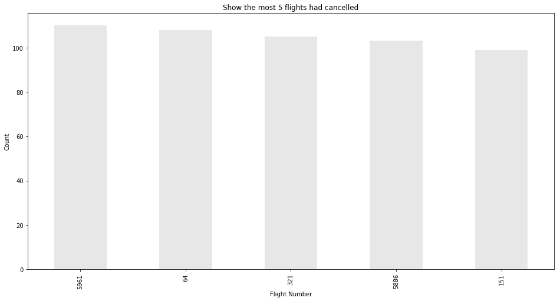

```python
fig, ax = plt.subplots(figsize=(16,8))
FlightNum_series.value_counts()[:5].plot.bar(ax=ax, color=(0.1, 0.1, 0.1, 0.1))
plt.title('Show the most 5 flights had cancelled')
plt.xlabel('Flight Number')
plt.ylabel('Count');
```

The above Flight numbers are the 5 most flight numbers are cancelled in the data set

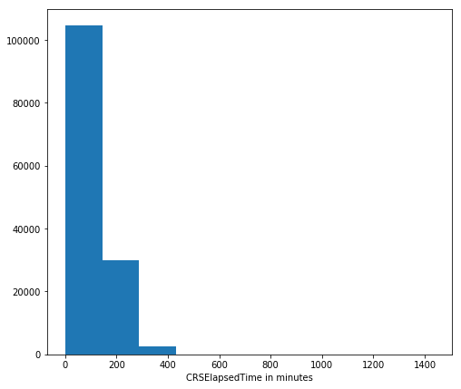

```python
# CRSElapsedTime(scheduled Elapsed Time) in minutes
# please note the column include NaN values
plt.figure(figsize=[8, 7])
plt.hist(df_flight_2008.CRSElapsedTime[~df_flight_2008.CRSElapsedTime.isna() & df_flight_2008.Cancelled == 1])
plt.xlabel('CRSElapsedTime in minutes');
```

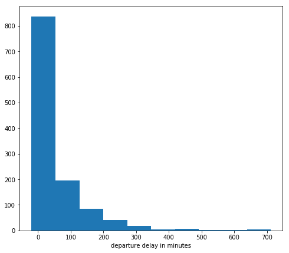

```python
# departure delay, in minutes
# please note the column include NaN values
plt.figure(figsize=[8, 7])
plt.hist(df_flight_2008.DepDelay[df_flight_2008.Cancelled == 1 & ~df_flight_2008.DepDelay.isna()])
plt.xlabel('departure delay in minutes');
```

The above 2 charts may be useless about cancellation info in this stage, but it show the scheduled Elapsed Time and departure delay of cancelation flights in minutes..

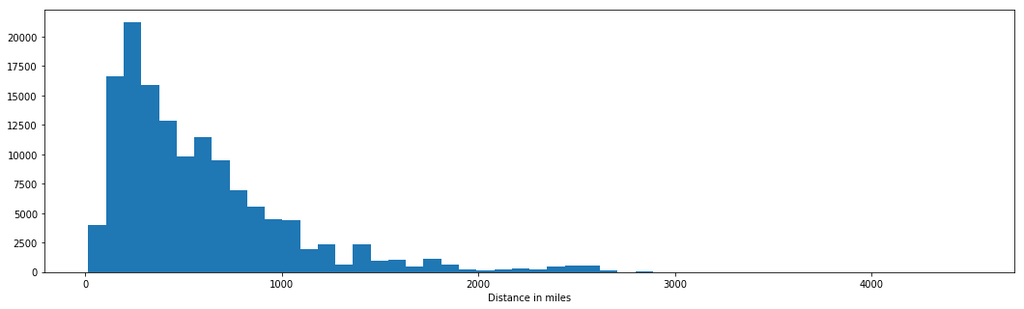

```python
# Distance(in miles)
# plot distribution of Distance(in miles) where there are cancalation
plt.figure(figsize=[18, 5])
plt.hist(df_flight_2008.Distance[df_flight_2008.Cancelled == 1], bins=50)
plt.xlabel('Distance in miles');
```

OR

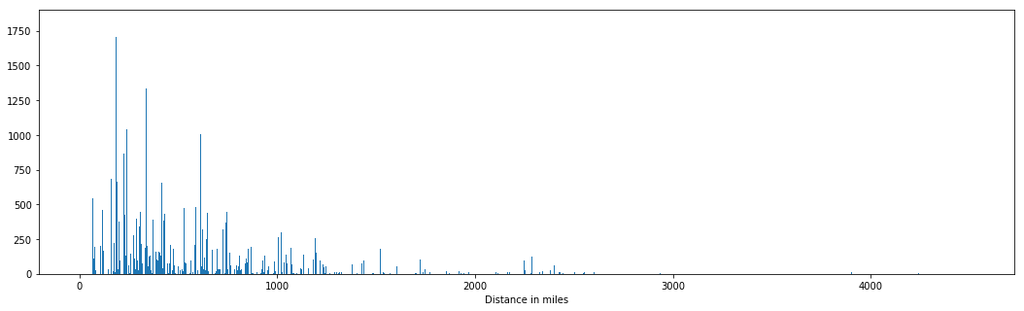

```python
# plot bars of Distance(in miles) where there are cancalation
Distance_series = df_flight_2008.Distance[df_flight_2008.Cancelled == 1]
dict_Distance_series = dict(Distance_series.value_counts())

plt.figure(figsize=[18, 5])
plt.bar(dict_Distance_series.keys(), dict_Distance_series.values())
plt.xlabel('Distance in miles');
```

```python
df_flight_2008.CancellationCode[df_flight_2008.Cancelled == 1].value_counts()
```

```
B    54904
A    54330
C    28188
D       12
Name: CancellationCode, dtype: int64
```

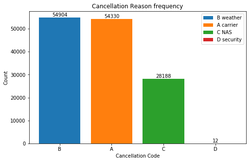

```python
# Cancellation Code
# CancellationCode: reason for cancellation (A = carrier, B = weather, C = NAS, D = security)
CancellationCode_series = df_flight_2008.CancellationCode[df_flight_2008.Cancelled == 1]
dict_CancellationCode_series = dict(CancellationCode_series.value_counts())

CancellationCode = {'A':'carrier', 'B':'weather', 'C':'NAS', 'D':'security'}

plt.figure(figsize=[8, 5])
for key in dict_CancellationCode_series.keys():
    key_value = dict_CancellationCode_series.get(key)
    plt.bar(key, key_value, label=key+' '+CancellationCode.get(key))
    plt.text(key, key_value, str(key_value), ha='center', va='bottom')
plt.legend()
plt.title('Cancellation Reason frequency')
plt.xlabel('Cancellation Code')
plt.ylabel('Count');
```

From above we can generally conclude that the most reason for cancellation because of weather or carrier.

```python
# check NaN for both origin and dest airport
print(df_flight_2008.Origin[df_flight_2008.Cancelled == 1].isnull().sum())
print(df_flight_2008.Dest[df_flight_2008.Cancelled == 1].isnull().sum())
```

```
0
0
```

```python
df_flight_2008.Origin[df_flight_2008.Cancelled == 1].value_counts()[:30]
```

```
ORD    15050
DFW     7272
ATL     5830
LGA     5753
EWR     4511
BOS     3655
IAH     3261
JFK     3196
LAX     2838
SFO     2790
DCA     2735
DEN     2725
DTW     2583
IAD     2077
LAS     2057
CLT     1986
PHL     1969
PHX     1875
CVG     1853
MSP     1729
HOU     1584
MEM     1516
CLE     1359
STL     1316
RDU     1253
SAN     1251
MDW     1246
MKE     1200
SEA     1142
SLC     1090
Name: Origin, dtype: int64
```

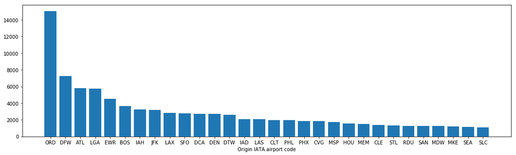

```python
# origin IATA airport code
# Origin is categorical data
Origin_series = df_flight_2008.Origin[df_flight_2008.Cancelled == 1].value_counts()[:30]
dict_Origin_series = dict(Origin_series)

plt.figure(figsize=[18, 5])
plt.bar(dict_Origin_series.keys(), dict_Origin_series.values())
plt.xlabel('Origin IATA airport code'); # please refer to data source for any info of the column http://stat-computing.org/dataexpo/2009/the-data.html
```

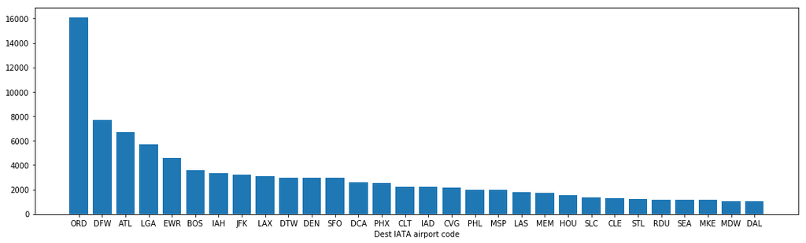

```python
# destination IATA airport code
# Dest is categorical data
Dest_series = df_flight_2008.Dest[df_flight_2008.Cancelled == 1].value_counts()[:30]
dict_Dest_series = dict(Dest_series)

plt.figure(figsize=[18, 5])
plt.bar(dict_Dest_series.keys(), dict_Dest_series.values())
plt.xlabel('Dest IATA airport code'); # please refer to data source for any info of the column http://stat-computing.org/dataexpo/2009/the-data.html
```

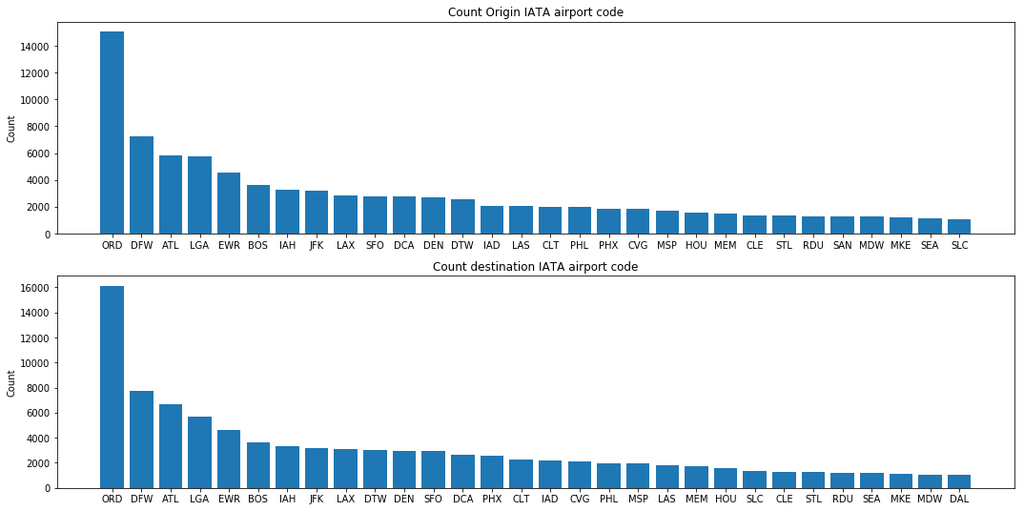

```python
# origin IATA airport code
# Origin is categorical data
Origin_series = df_flight_2008.Origin[df_flight_2008.Cancelled == 1].value_counts()[:30]
dict_Origin_series = dict(Origin_series)

plt.figure(figsize=[18, 9])
plt.subplot(2, 1, 1)
plt.bar(dict_Origin_series.keys(), dict_Origin_series.values())
plt.title('Count Origin IATA airport code')
plt.ylabel('Count'); # please refer to data source for any info of the column http://stat-computing.org/dataexpo/2009/the-data.html

# destination IATA airport code
# Dest is categorical data
Dest_series = df_flight_2008.Dest[df_flight_2008.Cancelled == 1].value_counts()[:30]
dict_Dest_series = dict(Dest_series)

plt.subplot(2, 1, 2)
plt.bar(dict_Dest_series.keys(), dict_Dest_series.values())
plt.title('Count destination IATA airport code')
plt.ylabel('Count'); # please refer to data source for any info of the column http://stat-computing.org/dataexpo/2009/the-data.html
```

From above 2 charts I show the most origin and destination airport of cancellation flights

### Discuss the distribution(s) of your variable(s) of interest. Were there any unusual points? Did you need to perform any transformations?

> Actullay there is no unusual points but there was NaN values in some columns when there are cancellation but may these columns are not effect the canacellation prosses because they are relate to flight times (which are DepDelay-departure delay, in minutes and CRSElapsedTime-(scheduled Elapsed Time) in minutes), otherwise every thing look normal.

### Of the features you investigated, were there any unusual distributions? Did you perform any operations on the data to tidy, adjust, or change the form of the data? If so, why did you do this?

> The columns include NaN minutes values, I show the non nan values of departure delay and scheduled Elapsed Time.

## Bivariate Exploration

```python
# let first have df with only cancelation flights
df_flight_2008_cancellation = df_flight_2008[df_flight_2008.Cancelled == 1]
```

```python
df_flight_2008_cancellation.dropna(axis=1).shape
```

```
(137434, 14)
```

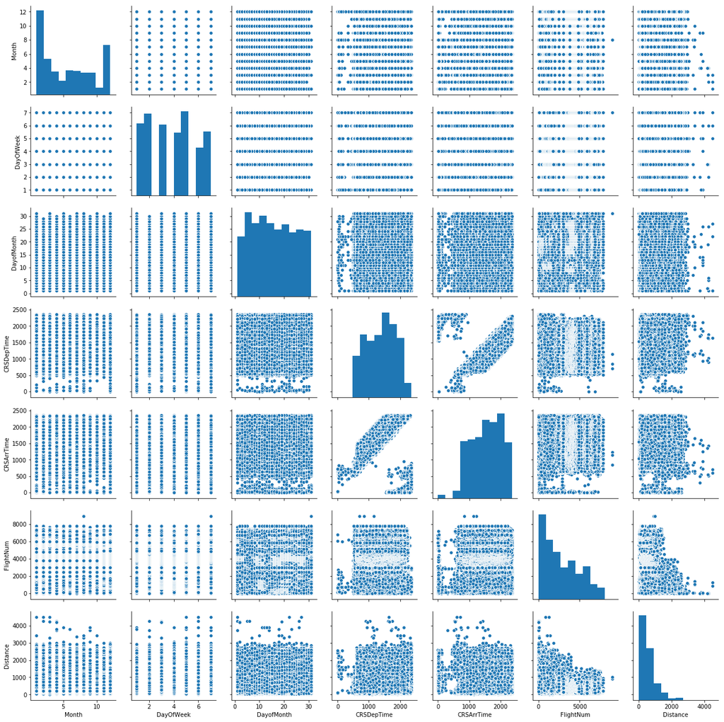

```python
sns.pairplot(df_flight_2008_cancellation[['Month', 'DayOfWeek', 'DayofMonth', 'CRSDepTime', 'CRSArrTime', 'UniqueCarrier', 'FlightNum', 'Distance', 'CancellationCode', 'Origin', 'Dest']])
```

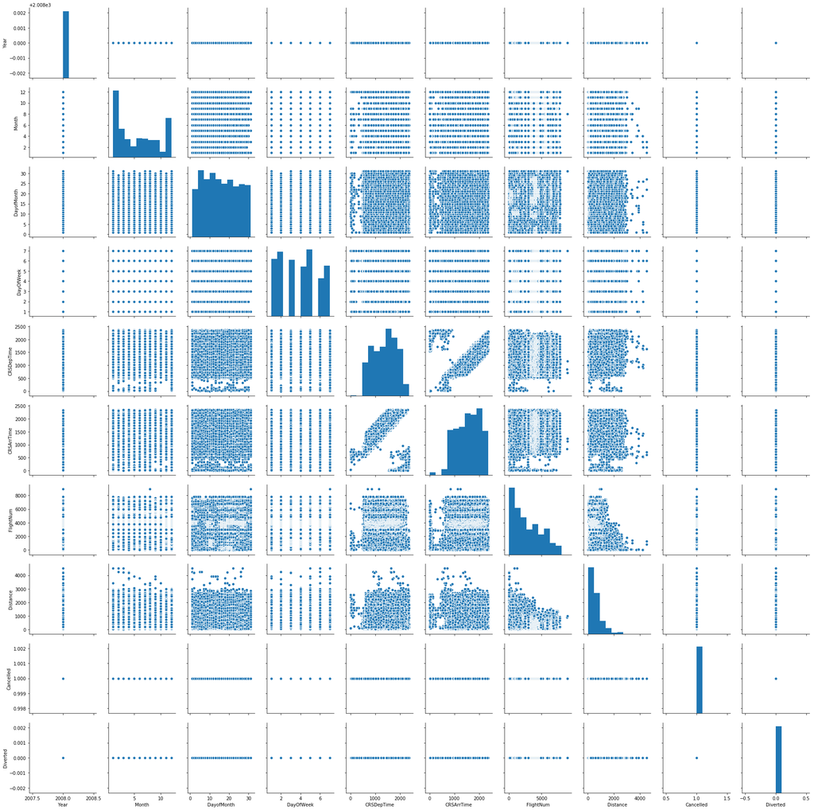

```python
sns.pairplot(df_flight_2008_cancellation.dropna(axis=1))
```

Because the target variable are categorical so we will group by variables to find insights

plot for each month which day of year or day of month are the highest day of cancellation

```python
df_month_dayweek_counts = df_flight_2008_cancellation[['Month','DayOfWeek']].groupby(['Month','DayOfWeek'])[['DayOfWeek']].sum()
```

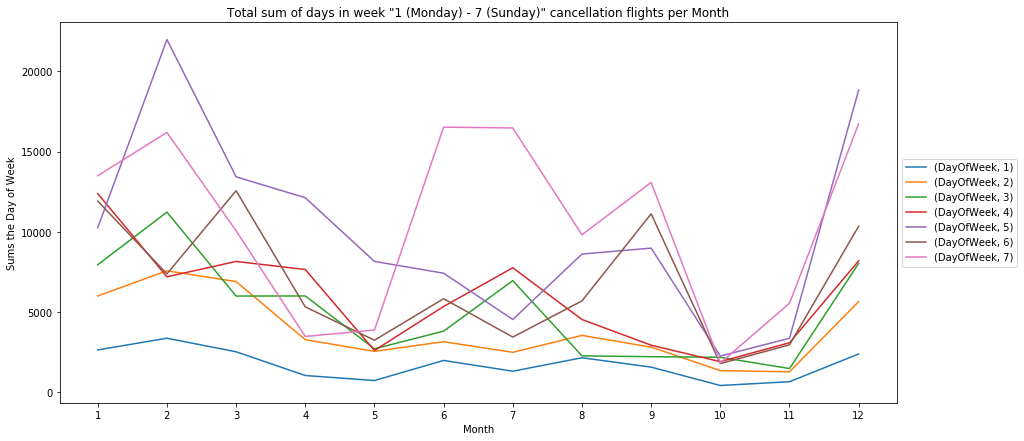

```python
# plot data
fig, ax = plt.subplots(figsize=(15,7))
df_month_dayweek_counts.unstack().plot(ax=ax)
plt.xticks(range(1,13))
plt.legend(loc='center left', bbox_to_anchor=(1, 0.5))
plt.title('Total sum of days in week "1 (Monday) - 7 (Sunday)" cancellation flights per Month')
plt.ylabel('Sums the Day of Week');
```

From above graph, in months 2(February), 6(June), 7(July), and 12(December) of day 5 for February & December, and day 7 for June & July have peak values, so we conclude the most cnacellation happen in the friday and sunday of February, June, July, and December, but the most cancellation month is February.

```python
df_month_daymonth_counts = df_flight_2008_cancellation[['Month','DayofMonth']].groupby(['Month','DayofMonth'])[['DayofMonth']].sum()
```

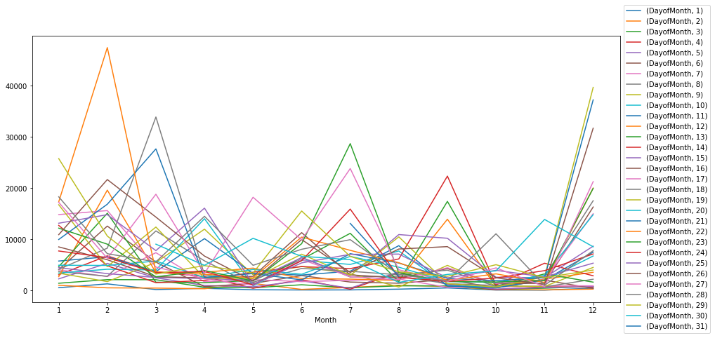

```python
# plot data
fig, ax = plt.subplots(figsize=(15,7))
df_month_daymonth_counts.unstack().plot(ax=ax)
plt.xticks(range(1,13))
plt.legend(loc='center left', bbox_to_anchor=(1, 0.5));
```

Because we have 31 day of month the graph above have lots of lines and this will mislead users so in this stage we will not use Day of Month, but we can fighure the 2(Ferbrurary) moth have the most cancellation.

```python
# show each month and its cancellation reason
df_flight_2008_cancellation[['Month','CancellationCode']].groupby(['Month','CancellationCode'])[['CancellationCode']].count()
```

| Month | CancellationCode | CancellationCode |
| --- | --- | --- |
| 1 | A | 6635 |
|  | B | 6711 |
|  | C | 3962 |
| 2 | A | 6090 |
|  | B | 10034 |
|  | C | 4470 |
|  | D | 2 |
| 3 | A | 6038 |
|  | B | 7520 |
|  | C | 2621 |
|  | D | 4 |
| 4 | A | 7312 |
|  | B | 1479 |
|  | C | 1564 |
| 5 | A | 3157 |
|  | B | 1461 |
|  | C | 1608 |
|  | D | 3 |
| 6 | A | 4251 |
|  | B | 3448 |
|  | C | 3232 |
| 7 | A | 5292 |
|  | B | 2612 |
|  | C | 2694 |
| 8 | A | 3852 |
|  | B | 3582 |
|  | C | 2401 |
| 9 | A | 2246 |
|  | B | 6478 |
|  | C | 1188 |
|  | D | 1 |
| 10 | A | 2097 |
|  | B | 600 |
|  | C | 552 |
| 11 | A | 2510 |
|  | B | 937 |
|  | C | 1009 |
|  | D | 2 |
| 12 | A | 4850 |
|  | B | 10042 |
|  | C | 2887 |

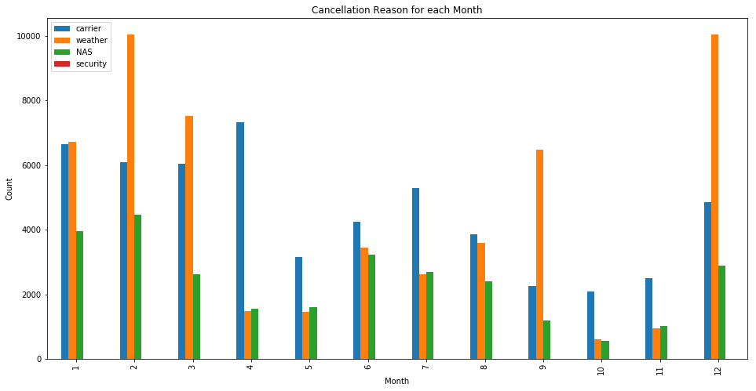

```python
fig, ax = plt.subplots(figsize=(16,8))
df_flight_2008_cancellation[['Month','CancellationCode']].groupby(['Month','CancellationCode'])[['CancellationCode']].count().unstack().plot.bar(ax=ax)
plt.title('Cancellation Reason for each Month') #  A:carrier, B:weather, C:NAS, D:security
plt.ylabel('Count');
plt.legend(CancellationCode.values());
```

We can see that the most Month have flight cancelation are 2 and 12 in 2008 year, and the cancelled reason is weather, carrier then NAS (National Airspace System)

Show the CancellationCode for each UniqueCarrier

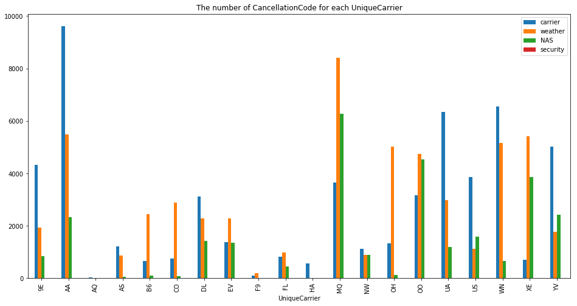

```python
fig, ax = plt.subplots(figsize=(16,8))
df_flight_2008_cancellation[['UniqueCarrier','CancellationCode']].groupby(['UniqueCarrier','CancellationCode'])[['CancellationCode']].count().unstack().plot.bar(ax=ax)
plt.title('The number of CancellationCode for each UniqueCarrier') #  A:carrier, B:weather, C:NAS, D:security
plt.legend(CancellationCode.values());
```

From above chart,

```
- carrier is the most effect cause of cnancellation in "AA"
- weather is the most effect cause of cnancellation in "MQ"
```

Showing the mean of Distance(in miles) for each CancellationCode

```python
df_flight_2008_cancellation.Distance.describe()
```

```
count    137434.000000
mean        581.042842
std         457.886379
min          17.000000
25%         256.000000
50%         448.000000
75%         749.000000
max        4502.000000
Name: Distance, dtype: float64
```

```python
df_flight_2008_cancellation[['Distance','CancellationCode']].groupby(['CancellationCode'])[['Distance']].mean()
```

| CancellationCode | Distance |
| --- | --- |
| A | 634.408467 |
| B | 584.562145 |
| C | 471.271286 |
| D | 719.583333 |

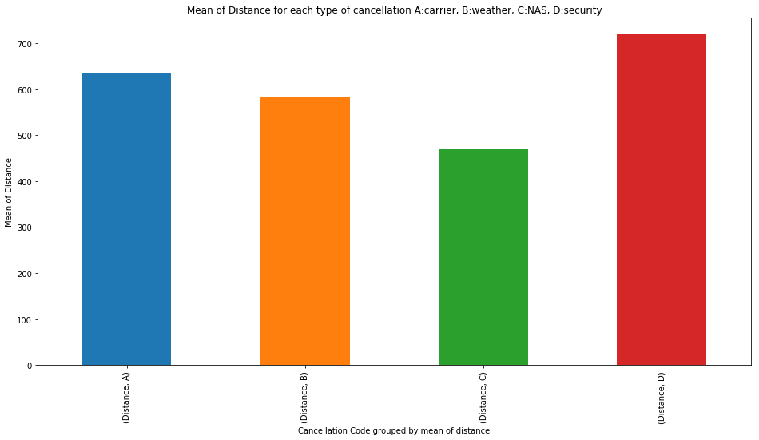

```python
fig, ax = plt.subplots(figsize=(16,8))
df_flight_2008_cancellation[['Distance','CancellationCode']].groupby(['CancellationCode'])[['Distance']].mean().unstack().plot.bar(ax=ax)
plt.title('Mean of Distance for each type of cancellation A:carrier, B:weather, C:NAS, D:security')
plt.xlabel('Cancellation Code grouped by mean of distance')
plt.ylabel('Mean of Distance');
```

### Talk about some of the relationships you observed in this part of the investigation. How did the feature(s) of interest vary with other features in the dataset?

> Day of week/month each have specific insght to tell. UniqueCarrier with CancellationCode show us what is the CancellationCode Carrier have. We observe from the mean of distances belonge to which CancellationCode.

### Did you observe any interesting relationships between the other features (not the main feature(s) of interest)?

> In this stage no, may in Multivariate Exploration the Origin and Dest features show any interesting.

## Multivariate Exploration

```python
df_flight_2008_cancellation[['UniqueCarrier', 'CancellationCode', 'Distance']].groupby(['UniqueCarrier', 'CancellationCode'])[['Distance']].mean()
```

| UniqueCarrier | CancellationCode | Distance |
| --- | --- | --- |
| 9E | A | 448.833218 |
|  | B | 404.557971 |
|  | C | 427.503580 |
|  | D | 696.000000 |
| AA | A | 969.174004 |
|  | B | 873.276615 |
|  | C | 893.883462 |
|  | D | 2342.000000 |
| AQ | A | 700.833333 |
| AS | A | 784.486088 |
|  | B | 762.709827 |
|  | C | 1011.211538 |
| B6 | A | 959.515789 |
|  | B | 964.315746 |
|  | C | 830.915789 |
| CO | A | 904.947721 |
|  | B | 961.293954 |
|  | C | 881.294872 |
| DL | A | 686.615483 |
|  | B | 685.186159 |
|  | C | 474.816514 |
| EV | A | 410.098266 |
|  | B | 487.458607 |
|  | C | 405.333088 |
|  | D | 171.000000 |
| F9 | A | 755.275229 |
|  | B | 893.026042 |
|  | C | 846.000000 |
| FL | A | 614.436810 |
|  | B | 675.907787 |
|  | C | 651.141573 |
| HA | A | 195.008881 |
|  | B | 2298.571429 |
| MQ | A | 412.286224 |
|  | B | 371.076713 |
|  | C | 360.438247 |
|  | D | 506.500000 |
| NW | A | 564.117069 |
|  | B | 488.833518 |
|  | C | 587.067720 |
| OH | A | 473.130271 |
|  | B | 477.751994 |
|  | C | 543.796610 |
| OO | A | 397.303922 |
|  | B | 337.225569 |
|  | C | 309.286630 |
|  | D | 237.000000 |
| UA | A | 891.342569 |
|  | B | 807.176096 |
|  | C | 680.324459 |
| US | A | 650.112523 |
|  | B | 615.465075 |
|  | C | 466.960477 |
| WN | A | 460.691181 |
|  | B | 609.320302 |
|  | C | 448.891892 |
|  | D | 325.000000 |
| XE | A | 582.763271 |
|  | B | 523.670170 |
|  | C | 548.244640 |
| YV | A | 378.371514 |
|  | B | 312.672707 |
|  | C | 368.341965 |

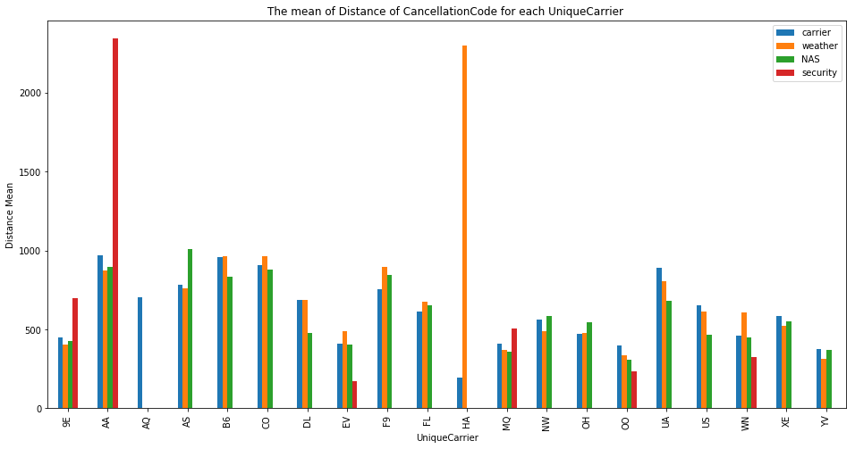

```python
fig, ax = plt.subplots(figsize=(16,8))
df_flight_2008_cancellation[['UniqueCarrier', 'CancellationCode', 'Distance']].groupby(['UniqueCarrier', 'CancellationCode'])[['Distance']].mean().unstack().plot.bar(ax=ax)
plt.title('The mean of Distance of CancellationCode for each UniqueCarrier ') #  A:carrier, B:weather, C:NAS, D:security
plt.ylabel('Distance Mean')
plt.legend(CancellationCode.values());
```

for each UniqueCarrier in the dataset shows the mean of distance of each CancellationCode.

```python
# number of trips (that cancelled) for each flight number with mean of distances + the cancellation code relate to UniqueCarrier
df_flight_2008_cancellation[['Distance', 'FlightNum', 'UniqueCarrier', 'CancellationCode']].groupby(['UniqueCarrier', 'CancellationCode','FlightNum'])[['Distance']].mean().nlargest(20, 'Distance')
```

| UniqueCarrier | CancellationCode | FlightNum | Distance |
| --- | --- | --- | --- |
| DL | A | 850 | 4502.0 |
|  |  | 1282 | 4502.0 |
| AA | B | 72 | 4243.0 |
|  |  | 73 | 4243.0 |
| UA | A | 1 | 4243.0 |
| CO | A | 1 | 3904.0 |
|  | B | 1 | 3904.0 |
|  |  | 2 | 3904.0 |
|  |  | 72 | 3904.0 |
|  |  | 73 | 3904.0 |
| AA | A | 5 | 3784.0 |
|  |  | 8 | 3784.0 |
|  |  | 102 | 3784.0 |
|  |  | 6 | 3711.0 |
|  |  | 7 | 3711.0 |
| UA | A | 1015 | 3414.0 |
|  |  | 1016 | 3414.0 |
|  |  | 1040 | 3414.0 |
| AA | A | 73 | 3365.0 |
| UA | A | 3 | 3173.5 |

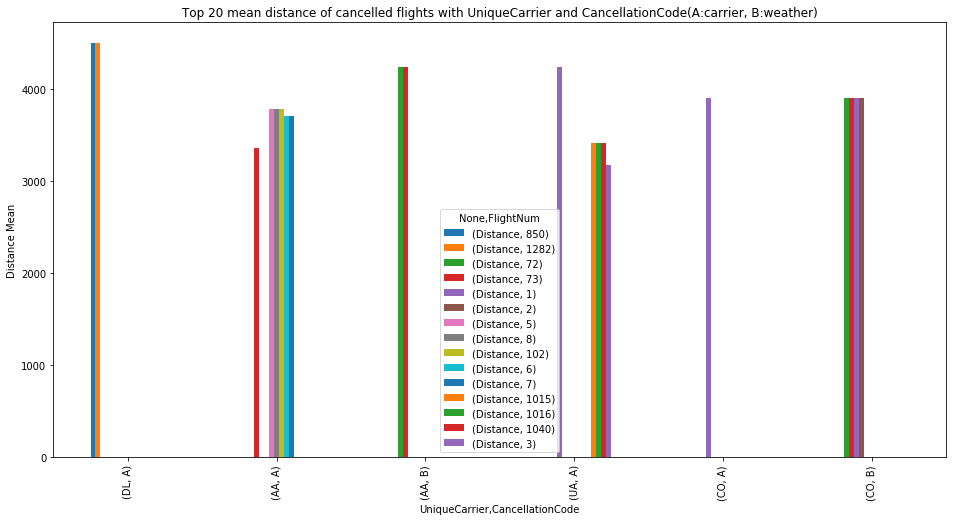

```python
fig, ax = plt.subplots(figsize=(16,8))
df_flight_2008_cancellation[['Distance', 'FlightNum', 'UniqueCarrier', 'CancellationCode']].groupby(['UniqueCarrier', 'CancellationCode', 'FlightNum'])[['Distance']].mean().nlargest(20, 'Distance').unstack().plot.bar(ax=ax)
plt.title('Top 20 mean distance of cancelled flights with UniqueCarrier and CancellationCode(A:carrier, B:weather)') #  A:carrier, B:weather, C:NAS, D:security
plt.ylabel('Distance Mean');
```

```python
df_flight_2008_cancellation[['FlightNum', 'UniqueCarrier', 'CancellationCode']].groupby(['UniqueCarrier', 'CancellationCode', 'FlightNum'])[['FlightNum']].count().nlargest(20, 'FlightNum')
```

| UniqueCarrier | CancellationCode | FlightNum | FlightNum |
| --- | --- | --- | --- |
| OO | C | 5961 | 82 |
|  |  | 5886 | 73 |
|  |  | 6153 | 69 |
|  |  | 5946 | 68 |
|  |  | 5944 | 61 |
| YV | B | 7098 | 54 |
|  |  | 7151 | 54 |
| CO | B | 1115 | 49 |
| OO | C | 6476 | 49 |
|  |  | 5802 | 48 |
| XE | C | 2665 | 48 |
|  |  | 2874 | 48 |
| OO | C | 6024 | 47 |
| CO | B | 1114 | 46 |
| XE | C | 3074 | 46 |
| OO | C | 6077 | 45 |
| XE | C | 3142 | 45 |
| OO | C | 5452 | 43 |
|  |  | 6023 | 43 |
| XE | C | 2521 | 43 |

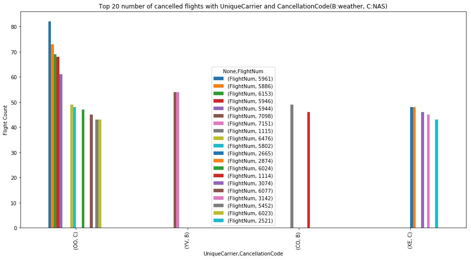

```python
# the most 20 number of trips/flight (that cancelled) for each flight number with cancellation code relate to UniqueCarrier
fig, ax = plt.subplots(figsize=(16,8))
df_flight_2008_cancellation[['FlightNum', 'UniqueCarrier', 'CancellationCode']].groupby(['UniqueCarrier', 'CancellationCode', 'FlightNum'])[['FlightNum']].count().nlargest(20, 'FlightNum').unstack().plot.bar(ax=ax)
plt.title('Top 20 number of cancelled flights with UniqueCarrier and CancellationCode(B:weather, C:NAS)') #  A:carrier, B:weather, C:NAS, D:security
plt.ylabel('Flight Count');
```

### Talk about some of the relationships you observed in this part of the investigation. Were there features that strengthened each other in terms of looking at your feature(s) of interest?

> The reason of cancellation within Unique carrier for each trip shows the famous reason of trip cancelled.